# Sensor_Data_Feature_Engineering

Finding the varaibles that are of the significance.

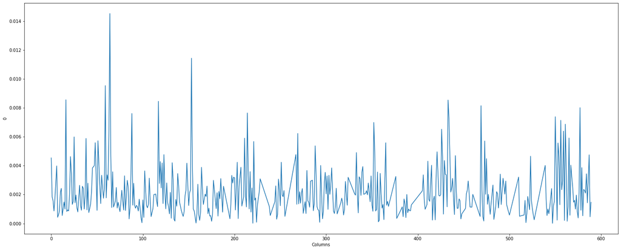

```python
df_importance=pd.DataFrame(classifier3.feature_importances_,index=X_train_old.columns)
df_importance['Columns']=X_train_old.columns
df_show=df_importance[df_importance[0]>0.000]
plt.figure(figsize=(25,10))
sns.lineplot(x=df_show['Columns'],y=df_show[0],data=df_show,);
```

**We can see that majority of points have importance between 0.001 to 0.004**

**Calculating cross validation score for all the models**

```python
# Calculating the k-Fold cross validation score, here for each model 10 folds will be
# made for the data and there will be 10 iterations and the model will generate score for 10 Test-train set
# So we will take average for the all scores generated and see which model gives better score
# NOte: We are considering train Test only on the un-reduced dimensional data.

score9=cross_val_score(classifier1,initial_data,Y,cv=10).mean()
print("Cross validation score for Logistic Regression",score9)
score10=cross_val_score(classifier2,initial_data,Y,cv=10).mean()
print("Cross validation score for decision Tree",score10)
score11=cross_val_score(classifier3,initial_data,Y,cv=10).mean()
print("Cross validation score for Random forest",score11)
score12=cross_val_score(classifier4,initial_data,Y,cv=10).mean()
print("Cross validation score for SVC",score12)
```

```
Cross validation score for Logistic Regression 0.8233504817899723
Cross validation score for decision Tree 0.8124326310632043
Cross validation score for Random forest 0.9272619630899885
Cross validation score for SVC 0.9336354728074474
```

**Training for the dataframe with reduced dimensions**

Step1: Train the model with Training set

Step2: perform hyperform Hyperparameter tuning on th evaluation set.

Step3: Make the final prediction on the test.

```python
# Building Model for the reduced dataframe

classifier5=LogisticRegression();
classifier6=DecisionTreeClassifier();
classifier7=RandomForestClassifier();
classifier8=svm.SVC();
```

```python
#Finding the best parameter for training the models

param1={'C': [0.001, 0.01, 0.1, 1, 10],
        'fit_intercept':[True,False],
        'max_iter':[10,50,100,150],
        'tol':[0.0001,0.001,0.01,0.1,1],
         'verbose':[False,True]}

param2={'ccp_alpha':[0.001, 0.01, 0.1, 1, 10],
         'criterion':['gini','entropy'],
        'max_depth':[None,1,2,3],
        'max_features':[None,1,2,3,4,5],
        'max_leaf_nodes':[None,1,2,3,4,5],
        'min_impurity_decrease':[0.001, 0.01, 0.1, 1, 10]
        }

param3={'bootstrap':[True,False],
        'criterion':['gini','entropy'],
        'max_depth':[1,2,3],
        'max_features':['auto','sqrt'],
        'max_leaf_nodes':[None,1,2],
        'max_samples':[None,1,3,5],
        'n_estimators':[100,150]}

param4={'C':[0.01,0.1, 1,5, 10],
        'break_ties':[False,True],
        'cache_size':[200,100],
        'degree':[1,3,2],
        'gamma':['scale','auto'],
        'max_iter':[1,-1,5],
        'shrinking':[False,True]}


gcv1=GridSearchCV(classifier5, param1, cv=10,n_jobs=4,verbose=3)
gcv2=GridSearchCV(classifier6, param2, cv=10,n_jobs=4,verbose=3)
gcv3=GridSearchCV(classifier7, param3, cv=10,n_jobs=4,verbose=3)
gcv4=GridSearchCV(classifier8, param4, cv=10,n_jobs=4,verbose=3)
```

```python
gcv1.fit(X_eval_new,Y_eval_new)
print(gcv1.best_params_)
```

```
Fitting 10 folds for each of 400 candidates, totalling 4000 fits
{'C': 0.001, 'fit_intercept': True, 'max_iter': 10, 'tol': 0.0001, 'verbose': False}
```

```python
gcv2.fit(X_eval_new,Y_eval_new)
print(gcv2.best_params_)
```

```
Fitting 10 folds for each of 7200 candidates, totalling 72000 fits
{'ccp_alpha': 0.01, 'criterion': 'entropy', 'max_depth': None, 'max_features': 4, 'max_leaf_nodes': 5, 'min_impurity_decrease': 0.001}
```

```python
gcv3.fit(X_eval_new,Y_eval_new)
print(gcv3.best_params_)
```

```
Fitting 10 folds for each of 576 candidates, totalling 5760 fits
{'bootstrap': True, 'criterion': 'gini', 'max_depth': 1, 'max_features': 'auto', 'max_leaf_nodes': None, 'max_samples': None, 'n_estimators': 100}
```

```python
gcv4.fit(X_eval_new,Y_eval_new)
print(gcv4.best_params_)
```

```
Fitting 10 folds for each of 720 candidates, totalling 7200 fits
{'C': 0.01, 'break_ties': False, 'cache_size': 200, 'degree': 1, 'gamma': 'scale', 'max_iter': -1, 'shrinking': False}
```

```python
classifier9=LogisticRegression(C= 0.001, fit_intercept= True, max_iter= 10, tol= 0.0001, verbose= False);
classifier10=DecisionTreeClassifier(ccp_alpha= 0.001, criterion= 'gini', max_depth= None, max_features= 1, max_leaf_nodes= 4, min_impurity_decrease= 0.001);
classifier11=RandomForestClassifier(bootstrap= True, criterion= 'gini', max_depth= 1, max_features= 'auto', max_leaf_nodes= None, max_samples= None, n_estimators= 100);
classifier12=svm.SVC(C= 0.01, break_ties= False, cache_size= 200, degree= 1, gamma= 'scale', max_iter= -1, probability= True, shrinking= False);

# Model Fitting
classifier9.fit(X_train_new_os,Y_train_new_os);
classifier10.fit(X_train_new_os,Y_train_new_os);
classifier11.fit(X_train_new_os,Y_train_new_os);
classifier12.fit(X_train_new_os,Y_train_new_os);


#Checking the score for each scenario
score5=classifier9.score(X_test_new,Y_test_new)
score6=classifier10.score(X_test_new,Y_test_new)
score7=classifier11.score(X_test_new,Y_test_new)
score8=classifier12.score(X_test_new,Y_test_new)

#predicting the probability with which the model is able to classify the datapoints for each scenario
prob5=classifier9.fit(X_train_new_os,Y_train_new_os).predict_proba(X_test_new);
prob6=classifier10.fit(X_train_new_os,Y_train_new_os).predict_proba(X_test_new);
prob7=classifier11.fit(X_train_new_os,Y_train_new_os).predict_proba(X_test_new);
prob8=classifier12.fit(X_train_new_os,Y_train_new_os).predict_proba(X_test_new);

#Checking the predicted values for each scenario
y_pred5=classifier9.predict(X_test_new)
y_pred6=classifier10.predict(X_test_new)
y_pred7=classifier11.predict(X_test_new)
y_pred8=classifier12.predict(X_test_new)


#Confusion Matrix for analysing the classification done by models for each scenario
matrix5=confusion_matrix(Y_test_new,y_pred5);
matrix6=confusion_matrix(Y_test_new,y_pred6);
matrix7=confusion_matrix(Y_test_new,y_pred7);
matrix8=confusion_matrix(Y_test_new,y_pred8);

#roc score analysis for each model
fpr5,tpr5,threshold5=roc_curve(Y_test_new,prob5[:,1])
roc_auc5=auc(fpr5,tpr5);
fpr6,tpr6,threshold6=roc_curve(Y_test_new,prob6[:,1])
roc_auc6=auc(fpr6,tpr6);
fpr7,tpr7,threshold7=roc_curve(Y_test_new,prob7[:,1])
roc_auc7=auc(fpr7,tpr7);
fpr8,tpr8,threshold8=roc_curve(Y_test_new,prob8[:,1])
roc_auc8=auc(fpr8,tpr8);
```

**Confusion Matrix for analysing the classification done by models for each scenario**

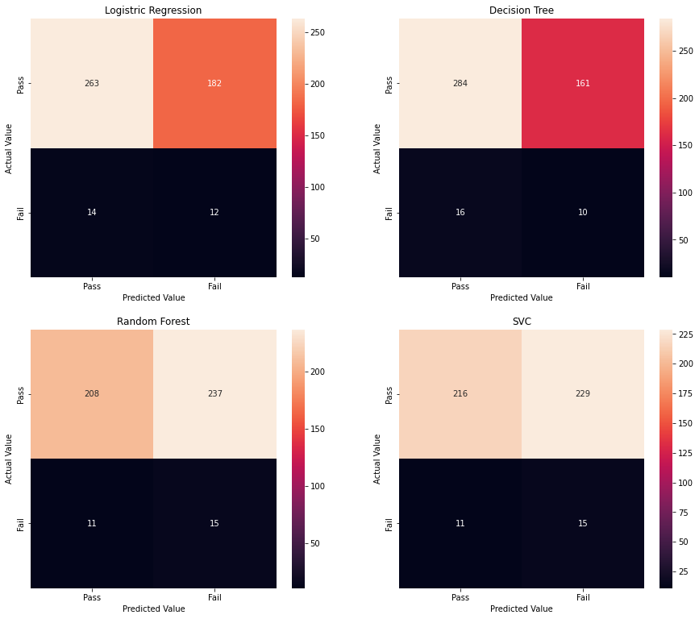

```python
plt.figure(figsize=(15,13))
plt.subplot(2,2,1);
ax=sns.heatmap(matrix5,annot=True,fmt='g');
ax.set_title('Logistric Regression');
ax.set_xlabel('Predicted Value');
ax.set_ylabel('Actual Value');
ax.xaxis.set_ticklabels(['Pass','Fail']);
ax.yaxis.set_ticklabels(['Pass','Fail']);

plt.subplot(2,2,2);
ax=sns.heatmap(matrix6,annot=True,fmt='g');
ax.set_title('Decision Tree');
ax.set_xlabel('Predicted Value');
ax.set_ylabel('Actual Value');
ax.xaxis.set_ticklabels(['Pass','Fail']);
ax.yaxis.set_ticklabels(['Pass','Fail']);

plt.subplot(2,2,3);
ax=sns.heatmap(matrix7,annot=True,fmt='g');
ax.set_title('Random Forest');
ax.set_xlabel('Predicted Value');
ax.set_ylabel('Actual Value');
ax.xaxis.set_ticklabels(['Pass','Fail']);
ax.yaxis.set_ticklabels(['Pass','Fail']);

plt.subplot(2,2,4);
ax=sns.heatmap(matrix8,annot=True,fmt='g');
ax.set_title('SVC');
ax.set_xlabel('Predicted Value');
ax.set_ylabel('Actual Value');
ax.xaxis.set_ticklabels(['Pass','Fail']);
ax.yaxis.set_ticklabels(['Pass','Fail']);
```